# Gender Recognition by Voice Using Logistic Regression

## Gender Recognition by Voice and Speech Analysis

### This database was created to identify a voice as male or female, based upon acoustic properties of the voice and speech. The dataset consists of 3,168 recorded voice samples, collected from male and female speakers. The voice samples are pre-processed by acoustic analysis in R using the seewave and tuneR packages, with an analyzed frequency range of 0hz-280hz (human vocal range).

## The Dataset

### The following acoustic properties of each voice are measured and included within the CSV:

- #### meanfreq: mean frequency (in kHz)
- #### sd: standard deviation of frequency
- #### median: median frequency (in kHz)
- #### Q25: first quantile (in kHz)
- #### Q75: third quantile (in kHz)
- #### IQR: interquantile range (in kHz)
- #### skew: skewness (see note in specprop description)
- #### kurt: kurtosis (see note in specprop description)
- #### sp.ent: spectral entropy
- #### sfm: spectral flatness
- #### mode: mode frequency
- #### centroid: frequency centroid (see specprop)
- #### peakf: peak frequency (frequency with highest energy)
- #### meanfun: average of fundamental frequency measured across acoustic signal
- #### minfun: minimum fundamental frequency measured across acoustic signal
- #### maxfun: maximum fundamental frequency measured across acoustic signal
- #### meandom: average of dominant frequency measured across acoustic signal
- #### mindom: minimum of dominant frequency measured across acoustic signal
- #### maxdom: maximum of dominant frequency measured across acoustic signal
- #### dfrange: range of dominant frequency measured across acoustic signal
- #### modindx: modulation index. Calculated as the accumulated absolute difference between adjacent measurements of fundamental frequencies divided by the frequency range
- #### label: male or female

## 1. We will use acoustic features to distinguish a male voice from female. Load the dataset from “voice.csv”,identify the target variable and do a one-hot encoding for the same. Split the dataset in train-test with 20% of the data kept aside for testing.

```python
import pandas as pd
import numpy as np
import matplotlib.pyplot as plt
import seaborn as sns
from sklearn.linear_model import LogisticRegression
from sklearn.model_selection import train_test_split
from sklearn.metrics import accuracy_score, confusion_matrix, classification_report
```

```python
df = pd.read_csv('voice.csv')
df.head()
```

|  | meanfreq | sd | median | Q25 | Q75 | IQR | skew | kurt | sp.ent | sfm | ... | centroid | meanfun | minfun | maxfun | meandom | mindom | maxdom | dfrange | modindx | label |
| --- | --- | --- | --- | --- | --- | --- | --- | --- | --- | --- | --- | --- | --- | --- | --- | --- | --- | --- | --- | --- | --- |
| 0 | 0.059781 | 0.064241 | 0.032027 | 0.015071 | 0.090193 | 0.075122 | 12.863462 | 274.402906 | 0.893369 | 0.491918 | ... | 0.059781 | 0.084279 | 0.015702 | 0.275862 | 0.007812 | 0.007812 | 0.007812 | 0.000000 | 0.000000 | male |
| 1 | 0.066009 | 0.067310 | 0.040229 | 0.019414 | 0.092666 | 0.073252 | 22.423285 | 634.613855 | 0.892193 | 0.513724 | ... | 0.066009 | 0.107937 | 0.015826 | 0.250000 | 0.009014 | 0.007812 | 0.054688 | 0.046875 | 0.052632 | male |
| 2 | 0.077316 | 0.083829 | 0.036718 | 0.008701 | 0.131908 | 0.123207 | 30.757155 | 1024.927705 | 0.846389 | 0.478905 | ... | 0.077316 | 0.098706 | 0.015656 | 0.271186 | 0.007990 | 0.007812 | 0.015625 | 0.007812 | 0.046512 | male |
| 3 | 0.151228 | 0.072111 | 0.158011 | 0.096582 | 0.207955 | 0.111374 | 1.232831 | 4.177296 | 0.963322 | 0.727232 | ... | 0.151228 | 0.088965 | 0.017798 | 0.250000 | 0.201497 | 0.007812 | 0.562500 | 0.554688 | 0.247119 | male |
| 4 | 0.135120 | 0.079146 | 0.124656 | 0.078720 | 0.206045 | 0.127325 | 1.101174 | 4.333713 | 0.971955 | 0.783568 | ... | 0.135120 | 0.106398 | 0.016931 | 0.266667 | 0.712812 | 0.007812 | 5.484375 | 5.476562 | 0.208274 | male |

5 rows × 21 columns

```python
df.info()
```

```
<class 'pandas.core.frame.DataFrame'>
RangeIndex: 3168 entries, 0 to 3167
Data columns (total 21 columns):
 #   Column    Non-Null Count  Dtype
---  ------    --------------  -----
 0   meanfreq  3168 non-null   float64
 1   sd        3168 non-null   float64
 2   median    3168 non-null   float64
 3   Q25       3168 non-null   float64
 4   Q75       3168 non-null   float64
 5   IQR       3168 non-null   float64
 6   skew      3168 non-null   float64
 7   kurt      3168 non-null   float64
 8   sp.ent    3168 non-null   float64
 9   sfm       3168 non-null   float64
 10  mode      3168 non-null   float64
 11  centroid  3168 non-null   float64
 12  meanfun   3168 non-null   float64
 13  minfun    3168 non-null   float64
 14  maxfun    3168 non-null   float64
 15  meandom   3168 non-null   float64
 16  mindom    3168 non-null   float64
 17  maxdom    3168 non-null   float64
 18  dfrange   3168 non-null   float64
 19  modindx   3168 non-null   float64
 20  label     3168 non-null   object
dtypes: float64(20), object(1)
memory usage: 519.9+ KB
```

### No missing values in our dataset.

### Using LabelEncoder to transform the Male/Female categorical variables

```python
from sklearn.preprocessing import LabelEncoder
le = LabelEncoder()
df.label = le.fit_transform(df.label)
df.head()
```

|  | meanfreq | sd | median | Q25 | Q75 | IQR | skew | kurt | sp.ent | sfm | ... | centroid | meanfun | minfun | maxfun | meandom | mindom | maxdom | dfrange | modindx | label |
| --- | --- | --- | --- | --- | --- | --- | --- | --- | --- | --- | --- | --- | --- | --- | --- | --- | --- | --- | --- | --- | --- |
| 0 | 0.059781 | 0.064241 | 0.032027 | 0.015071 | 0.090193 | 0.075122 | 12.863462 | 274.402906 | 0.893369 | 0.491918 | ... | 0.059781 | 0.084279 | 0.015702 | 0.275862 | 0.007812 | 0.007812 | 0.007812 | 0.000000 | 0.000000 | 1 |
| 1 | 0.066009 | 0.067310 | 0.040229 | 0.019414 | 0.092666 | 0.073252 | 22.423285 | 634.613855 | 0.892193 | 0.513724 | ... | 0.066009 | 0.107937 | 0.015826 | 0.250000 | 0.009014 | 0.007812 | 0.054688 | 0.046875 | 0.052632 | 1 |
| 2 | 0.077316 | 0.083829 | 0.036718 | 0.008701 | 0.131908 | 0.123207 | 30.757155 | 1024.927705 | 0.846389 | 0.478905 | ... | 0.077316 | 0.098706 | 0.015656 | 0.271186 | 0.007990 | 0.007812 | 0.015625 | 0.007812 | 0.046512 | 1 |
| 3 | 0.151228 | 0.072111 | 0.158011 | 0.096582 | 0.207955 | 0.111374 | 1.232831 | 4.177296 | 0.963322 | 0.727232 | ... | 0.151228 | 0.088965 | 0.017798 | 0.250000 | 0.201497 | 0.007812 | 0.562500 | 0.554688 | 0.247119 | 1 |
| 4 | 0.135120 | 0.079146 | 0.124656 | 0.078720 | 0.206045 | 0.127325 | 1.101174 | 4.333713 | 0.971955 | 0.783568 | ... | 0.135120 | 0.106398 | 0.016931 | 0.266667 | 0.712812 | 0.007812 | 5.484375 | 5.476562 | 0.208274 | 1 |

5 rows × 21 columns

```python
X = df.iloc[:, :-1]
y = df.iloc[:, -1]
```

```python
from sklearn.preprocessing import StandardScaler
scaler = StandardScaler()
X = pd.DataFrame(scaler.fit_transform(X), columns=X.columns)
```

```python
X_train, X_test, y_train, y_test = train_test_split(X, y, test_size=0.2, random_state=1)
```

## 2. Fit a logistic regression model and measure the accuracy on the test set.

```python
lr = LogisticRegression()
lr.fit(X_train, y_train)
y_pred = lr.predict(X_test)
```

```python
print(f"Accuracy Score: {accuracy_score(y_test, y_pred)}")
print(f"Classification Report:\n{classification_report(y_test, y_pred)}")
print(f"Confusion Matrix:\n{confusion_matrix(y_test, y_pred)}")
```

```
Accuracy Score: 0.9700315457413249
Classification Report:
              precision    recall  f1-score   support

           0       0.97      0.97      0.97       311
           1       0.97      0.97      0.97       323

    accuracy                           0.97       634
   macro avg       0.97      0.97      0.97       634
weighted avg       0.97      0.97      0.97       634

Confusion Matrix:
[[301  10]
 [  9 314]]
```

## 3. Compute the correlation matrix that describes the dependence between all predictors and identify the predictors that are highly correlated. Plot the correlation matrix using seaborn heatmap.

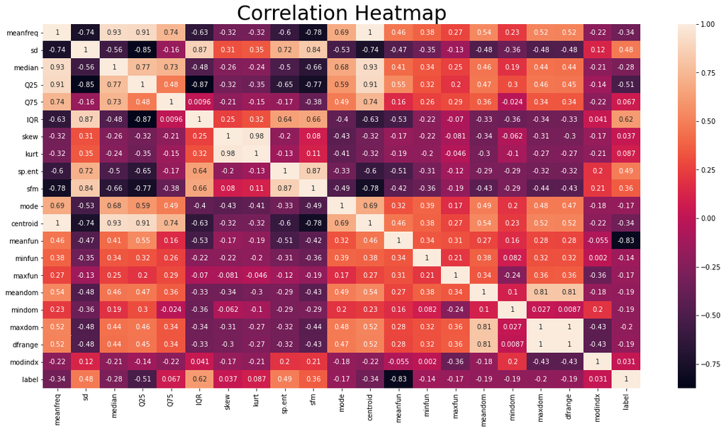

```python
plt.figure(figsize=(20,10))
plt.title('Correlation Heatmap', fontsize=30)
sns.heatmap(df.corr(), annot=True)
plt.show()
```

##### meanfreq/sfm: -0.78

##### Q25/sd: -0.85

##### centroid/median: 0.93

##### Q25/centroid: 0.91

##### Q25/IQR: -0.87

##### kurt/skew: 0.98

##### sfm/sp.ent: 0.87

##### centroid/sfm: -0.78

##### centroid/sd: -0.74

##### meandom/maxdom: 0.81

##### meandom/dfrange: 0.81

## 4. Based on correlation remove those predictors that are correlated and fit a logistic regression model again and compare the accuracy with that of previous model.

```python
X2 = X.drop(['Q25', 'centroid', 'meandom', 'kurt', 'meandom', 'meanfreq'], axis=1)
X2
```

|  | sd | median | Q75 | IQR | skew | sp.ent | sfm | mode | meanfun | minfun | maxfun | mindom | maxdom | dfrange | modindx |
| --- | --- | --- | --- | --- | --- | --- | --- | --- | --- | --- | --- | --- | --- | --- | --- |
| 0 | 0.427355 | -4.224901 | -5.693607 | -0.214778 | 2.293306 | -0.039083 | 0.471575 | -2.141210 | -1.812038 | -1.097998 | 0.565959 | -0.708404 | -1.431422 | -1.419137 | -1.454772 |
| 1 | 0.611669 | -3.999293 | -5.588987 | -0.258485 | 4.548056 | -0.065236 | 0.594431 | -2.141210 | -1.079594 | -1.091533 | -0.294030 | -0.708404 | -1.418107 | -1.405818 | -1.014103 |
| 2 | 1.603848 | -4.095851 | -3.928699 | 0.909326 | 6.513656 | -1.083730 | 0.398261 | -2.141210 | -1.365368 | -1.100397 | 0.410480 | -0.708404 | -1.429203 | -1.416917 | -1.065344 |
| 3 | 0.899998 | -0.759454 | -0.711205 | 0.632690 | -0.449858 | 1.516383 | 1.797340 | -1.054576 | -1.666966 | -0.988934 | -0.294030 | -0.708404 | -1.273867 | -1.261532 | 0.614286 |
| 4 | 1.322561 | -1.676948 | -0.792029 | 1.005588 | -0.480911 | 1.708336 | 2.114740 | -0.790514 | -1.127233 | -1.034015 | 0.260185 | -0.708404 | 0.124154 | 0.136933 | 0.289046 |
| ... | ... | ... | ... | ... | ... | ... | ... | ... | ... | ... | ... | ... | ... | ... | ... |
| 3163 | 1.658182 | -0.877839 | -0.999378 | 1.579141 | -0.325020 | 1.507749 | 1.999883 | 0.460602 | 1.237885 | 2.444087 | 0.114817 | -0.708404 | -0.237556 | -0.224892 | -0.098989 |
| 3164 | 1.927682 | -2.994482 | -0.840021 | 1.820721 | -0.577009 | 1.458418 | 1.697831 | -1.963949 | 1.429532 | -0.124536 | 0.565959 | -0.214641 | -0.388453 | -0.384717 | 0.871981 |
| 3165 | 2.322724 | -0.051973 | -0.017123 | 2.492666 | -0.298044 | 1.150198 | 1.385857 | -2.037497 | 2.077781 | 0.140728 | 0.565959 | -0.708404 | -0.599266 | -0.586717 | 0.175887 |
| 3166 | 2.012196 | -0.017728 | -0.204021 | 2.153653 | -0.365367 | 1.229850 | 1.505711 | 0.607848 | 0.915445 | -0.120678 | -0.294030 | -0.708404 | -0.412863 | -0.400255 | 1.149161 |
| 3167 | 2.147651 | -0.070879 | 1.102679 | 2.254671 | -0.338487 | 0.971759 | 1.089126 | 1.326841 | 1.325111 | 1.324614 | 0.410480 | -0.708404 | -1.276086 | -1.263752 | 1.475679 |

3168 rows × 15 columns

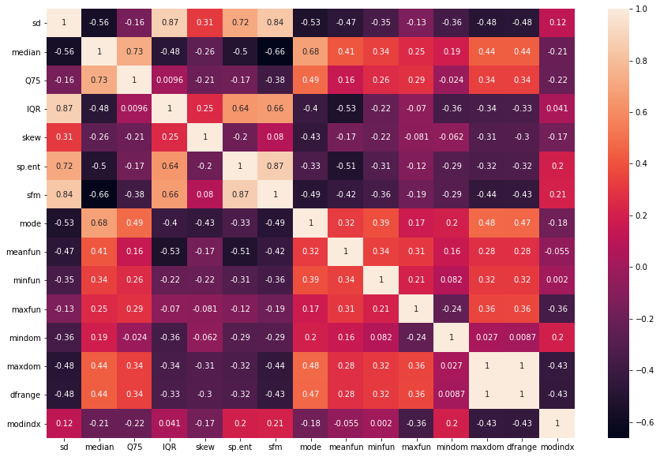

```python
plt.figure(figsize=(15,10))
sns.heatmap(X2.corr(), annot=True)
plt.show()
```

```python
X_train, X_test, y_train, y_test = train_test_split(X2, y, test_size=0.2, random_state=1)
```

```python
lr.fit(X_train, y_train)
y_pred = lr.predict(X_test)
```

```python
print(f"Accuracy Score: {accuracy_score(y_test, y_pred)}")
print(f"Classification Report:\n{classification_report(y_test, y_pred)}")
print(f"Confusion Matrix:\n{confusion_matrix(y_test, y_pred)}")
```

```
Accuracy Score: 0.973186119873817
Classification Report:
              precision    recall  f1-score   support

           0       0.97      0.97      0.97       311
           1       0.97      0.98      0.97       323

    accuracy                           0.97       634
   macro avg       0.97      0.97      0.97       634
weighted avg       0.97      0.97      0.97       634

Confusion Matrix:
[[302   9]
 [  8 315]]
```

### Removing highly correlated predictors increases the accuracy score.